# HW3_IS457_33

# Part 4. More functions in “apply” family (4pts)

# (14) “mapply” function is a multivariate version of “sapply”.

# Create list_2 by following code:

```r
list_2 <- list(a=one_matrix[,2],b=c(one_matrix[,3],one_matrix[,4]))
```

# Add up corresponding elements in list_1 and list_2, then take natural log of it. (2pts)

### Your code here

```r
mapply(function(x,y) log(sum(x+y)), list_1, list_2)
```

```
##       a       b
## 3.73767 4.65396
```

# (15) “rapply” function is used to apply a function to all elements of a list recursively.

# Create list_3 by following code:

```r
list_3 <- list(aa=one_matrix[,1],b=c("this","is","character"))
```

# Calculate the natural log of all integer in list_3. (2pts)

# Do not remove characters in the list or subsetting.

### Your code here

```r
rapply(list_3, log, classes = "integer")
```

```
##       aa1       aa2       aa3       aa4       aa5
## 0.6931472 0.6931472 0.0000000 1.6094379 2.1972246
```

# Part 5. Linear regression (9pts)

# (16) Look back in the “iris” dataset.

```r
data(iris)
```

# Fit a simple linear regression model using lm() to predict Petal.Length from Petal.Width. (2pts)

# How do you interpret the result of regression? Hint: interpret the two coefficients from the output of lm(). (2pts)

### Your code/answer here

```r
simple.lm=lm(iris$Petal.Length~iris$Petal.Width)
simple.lm
```

```
##
## Call:
## lm(formula = iris$Petal.Length ~ iris$Petal.Width)
##
## Coefficients:
##      (Intercept)  iris$Petal.Width
##            1.084             2.230
```

```r
# The intercept tells us that with a Petal Width of 0, the model predicts that the petal length will be 1.084.
# The next coefficient, "iris$Petal.Width" tells us that for every one unit that Petal Width increases, Petal Length will increase by 2.230.
```

# (17) Create a scatterplot with x-axis of Petal.Width and y-axis of Petal.Length. (2pt)

# Add the linear regression line you found above to the scatterplot. (1pt)

# Provide an interpretation for your plot. (2pts)

### Your code/answer here

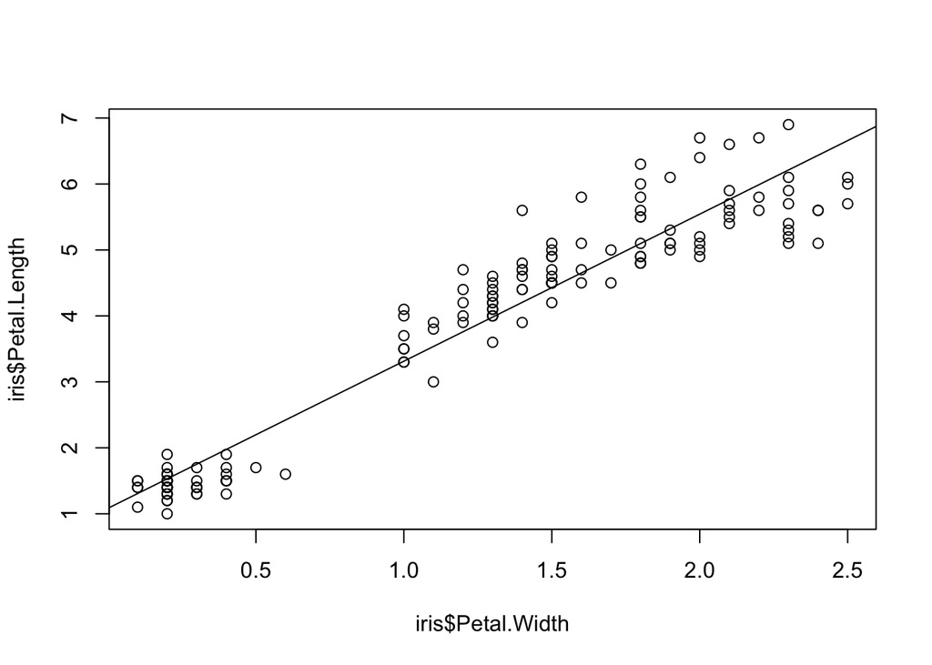

```r
plot(iris$Petal.Width, iris$Petal.Length)
abline(simple.lm)
```

```r
# This plot shows us the relationship between petal width and petal lenght. The regression line is the model that
# is fitted to the data, and we can see how well the trendline fits the data. We can see that there is a positive linear
# relationship between petal width and petal length.
```